# Project: Movies Data Analysis

- Introduction
- Data Wrangling
- Exploratory Data Analysis
- Conclusions

## Introduction

> Some of the question that we will try to get answers for are:
> 1. Is there a correlatin between movie budgets and revenue?
> 2. Is there a correlation between movie runtimes and revenue?
> 3. Is there a correlation between movie popularity and revenue?
> 4. Who are the top directors in terms of nuber of movies they made?
> 5. Is there a correlation between average revenue and directors?
> 6. Did all the movies made by a top director grossed higher revenue?
> 7. Is there a correlation between movie release year and revenue?

```python
# importing packages
import pandas as pd
import numpy as np
import matplotlib.pyplot as plt
%matplotlib inline
import seaborn as sns
import matplotlib
sns.set(style="ticks", color_codes=True)
```

## Data Wrangling

> 1. Let's load the data from tmdb-movies.csv into a dataframe and explore the data to try to find the data cleaning and trimming needs, based on what will serve us better when we will further analyze this data.

```python
# Read and load the tmdb-movies data into a dataframe.
df = pd.read_csv('tmdb-movies.csv')
```

```python
# Print out a few lines and perform operations to inspect data
df.head()
```

|  | id | imdb_id | popularity | budget | revenue | original_title | cast | homepage | director | tagline | ... | overview | runtime | genres | production_companies | release_date | vote_count | vote_average | release_year | budget_adj | revenue_adj |
| --- | --- | --- | --- | --- | --- | --- | --- | --- | --- | --- | --- | --- | --- | --- | --- | --- | --- | --- | --- | --- | --- |
| 0 | 135397 | tt0369610 | 32.985763 | 150000000 | 1513528810 | Jurassic World | Chris Pratt\|Bryce Dallas Howard\|Irrfan Khan\|Vi... | http://www.jurassicworld.com/ | Colin Trevorrow | The park is open. | ... | Twenty-two years after the events of Jurassic ... | 124 | Action\|Adventure\|Science Fiction\|Thriller | Universal Studios\|Amblin Entertainment\|Legenda... | 6/9/15 | 5562 | 6.5 | 2015 | 1.379999e+08 | 1.392446e+09 |
| 1 | 76341 | tt1392190 | 28.419936 | 150000000 | 378436354 | Mad Max: Fury Road | Tom Hardy\|Charlize Theron\|Hugh Keays-Byrne\|Nic... | http://www.madmaxmovie.com/ | George Miller | What a Lovely Day. | ... | An apocalyptic story set in the furthest reach... | 120 | Action\|Adventure\|Science Fiction\|Thriller | Village Roadshow Pictures\|Kennedy Miller Produ... | 5/13/15 | 6185 | 7.1 | 2015 | 1.379999e+08 | 3.481613e+08 |
| 2 | 262500 | tt2908446 | 13.112507 | 110000000 | 295238201 | Insurgent | Shailene Woodley\|Theo James\|Kate Winslet\|Ansel... | http://www.thedivergentseries.movie/#insurgent | Robert Schwentke | One Choice Can Destroy You | ... | Beatrice Prior must confront her inner demons ... | 119 | Adventure\|Science Fiction\|Thriller | Summit Entertainment\|Mandeville Films\|Red Wago... | 3/18/15 | 2480 | 6.3 | 2015 | 1.012000e+08 | 2.716190e+08 |
| 3 | 140607 | tt2488496 | 11.173104 | 200000000 | 2068178225 | Star Wars: The Force Awakens | Harrison Ford\|Mark Hamill\|Carrie Fisher\|Adam D... | http://www.starwars.com/films/star-wars-episod... | J.J. Abrams | Every generation has a story. | ... | Thirty years after defeating the Galactic Empi... | 136 | Action\|Adventure\|Science Fiction\|Fantasy | Lucasfilm\|Truenorth Productions\|Bad Robot | 12/15/15 | 5292 | 7.5 | 2015 | 1.839999e+08 | 1.902723e+09 |
| 4 | 168259 | tt2820852 | 9.335014 | 190000000 | 1506249360 | Furious 7 | Vin Diesel\|Paul Walker\|Jason Statham\|Michelle ... | http://www.furious7.com/ | James Wan | Vengeance Hits Home | ... | Deckard Shaw seeks revenge against Dominic Tor... | 137 | Action\|Crime\|Thriller | Universal Pictures\|Original Film\|Media Rights ... | 4/1/15 | 2947 | 7.3 | 2015 | 1.747999e+08 | 1.385749e+09 |

5 rows × 21 columns

> 1. Find the size of the data set and look for instances of missing or possibly errant data.

```python
# Check the size of the data set
df.shape
```

```
(10866, 21)
```

```python
# Check the count of values for each column and data type
df.info()
```

```
<class 'pandas.core.frame.DataFrame'>
RangeIndex: 10866 entries, 0 to 10865
Data columns (total 21 columns):
id                      10866 non-null int64
imdb_id                 10856 non-null object
popularity              10866 non-null float64
budget                  10866 non-null int64
revenue                 10866 non-null int64
original_title          10866 non-null object
cast                    10790 non-null object
homepage                2936 non-null object
director                10822 non-null object
tagline                 8042 non-null object
keywords                9373 non-null object
overview                10862 non-null object
runtime                 10866 non-null int64
genres                  10843 non-null object
production_companies    9836 non-null object
release_date            10866 non-null object
vote_count              10866 non-null int64
vote_average            10866 non-null float64
release_year            10866 non-null int64
budget_adj              10866 non-null float64
revenue_adj             10866 non-null float64
dtypes: float64(4), int64(6), object(11)
memory usage: 1.7+ MB
```

> There are some missing values in the columns like 'imdb_id','cast','homepage', etc...

```python
# Use describe to get some insights about min, max ...values
df.describe()
```

|  | id | popularity | budget | revenue | runtime | vote_count | vote_average | release_year | budget_adj | revenue_adj |
| --- | --- | --- | --- | --- | --- | --- | --- | --- | --- | --- |
| count | 10866.000000 | 10866.000000 | 1.086600e+04 | 1.086600e+04 | 10866.000000 | 10866.000000 | 10866.000000 | 10866.000000 | 1.086600e+04 | 1.086600e+04 |
| mean | 66064.177434 | 0.646441 | 1.462570e+07 | 3.982332e+07 | 102.070863 | 217.389748 | 5.974922 | 2001.322658 | 1.755104e+07 | 5.136436e+07 |
| std | 92130.136561 | 1.000185 | 3.091321e+07 | 1.170035e+08 | 31.381405 | 575.619058 | 0.935142 | 12.812941 | 3.430616e+07 | 1.446325e+08 |
| min | 5.000000 | 0.000065 | 0.000000e+00 | 0.000000e+00 | 0.000000 | 10.000000 | 1.500000 | 1960.000000 | 0.000000e+00 | 0.000000e+00 |
| 25% | 10596.250000 | 0.207583 | 0.000000e+00 | 0.000000e+00 | 90.000000 | 17.000000 | 5.400000 | 1995.000000 | 0.000000e+00 | 0.000000e+00 |
| 50% | 20669.000000 | 0.383856 | 0.000000e+00 | 0.000000e+00 | 99.000000 | 38.000000 | 6.000000 | 2006.000000 | 0.000000e+00 | 0.000000e+00 |
| 75% | 75610.000000 | 0.713817 | 1.500000e+07 | 2.400000e+07 | 111.000000 | 145.750000 | 6.600000 | 2011.000000 | 2.085325e+07 | 3.369710e+07 |
| max | 417859.000000 | 32.985763 | 4.250000e+08 | 2.781506e+09 | 900.000000 | 9767.000000 | 9.200000 | 2015.000000 | 4.250000e+08 | 2.827124e+09 |

```python
# Find out how many duplicate rows are present in the data set
sum(df.duplicated())
```

```
1
```

> There is 1 duplicate row.

```python
# Use nunique to get some info about number of unique values for each column
df.nunique()
```

```
id                      10865
imdb_id                 10855
popularity              10814
budget                    557
revenue                  4702
original_title          10571
cast                    10719
homepage                 2896
director                 5067
tagline                  7997
keywords                 8804
overview                10847
runtime                   247
genres                   2039
production_companies     7445
release_date             5909
vote_count               1289
vote_average               72
release_year               56
budget_adj               2614
revenue_adj              4840
dtype: int64
```

### Data Cleaning

```python
# put together a list of columns which needs to be deleted
col_delete = ['id','imdb_id','keywords', 'homepage', 'tagline', 'overview',
          'production_companies', 'budget', 'revenue','vote_count','vote_average']
```

```python
# drop the columns. Use inplace to make permanent changes.
df.drop(col_delete, axis=1, inplace=True)
```

> 1. Change the names of 'budget)adj' and 'revenue_adj' columns to more appropriate names like total_budget and total_revenue.

```python
#renaming to more descriptive coloumns.
df.rename(index=str, columns={"budget_adj": "total_budget", "revenue_adj": "total_revenue"}, inplace=True)
```

```python
# check the data set after deleting the specific columns.
df.head()
```

|  | popularity | original_title | cast | director | runtime | genres | release_date | release_year | total_budget | total_revenue |
| --- | --- | --- | --- | --- | --- | --- | --- | --- | --- | --- |
| 0 | 32.985763 | Jurassic World | Chris Pratt\|Bryce Dallas Howard\|Irrfan Khan\|Vi... | Colin Trevorrow | 124 | Action\|Adventure\|Science Fiction\|Thriller | 6/9/15 | 2015 | 1.379999e+08 | 1.392446e+09 |
| 1 | 28.419936 | Mad Max: Fury Road | Tom Hardy\|Charlize Theron\|Hugh Keays-Byrne\|Nic... | George Miller | 120 | Action\|Adventure\|Science Fiction\|Thriller | 5/13/15 | 2015 | 1.379999e+08 | 3.481613e+08 |
| 2 | 13.112507 | Insurgent | Shailene Woodley\|Theo James\|Kate Winslet\|Ansel... | Robert Schwentke | 119 | Adventure\|Science Fiction\|Thriller | 3/18/15 | 2015 | 1.012000e+08 | 2.716190e+08 |
| 3 | 11.173104 | Star Wars: The Force Awakens | Harrison Ford\|Mark Hamill\|Carrie Fisher\|Adam D... | J.J. Abrams | 136 | Action\|Adventure\|Science Fiction\|Fantasy | 12/15/15 | 2015 | 1.839999e+08 | 1.902723e+09 |
| 4 | 9.335014 | Furious 7 | Vin Diesel\|Paul Walker\|Jason Statham\|Michelle ... | James Wan | 137 | Action\|Crime\|Thriller | 4/1/15 | 2015 | 1.747999e+08 | 1.385749e+09 |

```python
# check the shape of the data set after deleting the specific colmuns
rows, col = df.shape
print('We now have only {} rows and {} columns'.format(rows-1, col))
```

```
We now have only 10865 rows and 10 columns
```

> 1. Remove the 1 row which is showing as duplicate.

```python
# delete the duplicate row and use implace to make the changes permanant
df.drop_duplicates(inplace=True)
#Check the number of duplicates. It should show 0.
sum(df.duplicated())
```

```
0
```

```python
# check the shape again
rows, col = df.shape
print('We now have {} rows and {} columns'.format(rows-1, col))
```

[output not shown]

```python
df.info()
```

```
<class 'pandas.core.frame.DataFrame'>
Index: 10865 entries, 0 to 10865
Data columns (total 10 columns):
popularity        10865 non-null float64
original_title    10865 non-null object
cast              10789 non-null object
director          10821 non-null object
runtime           10865 non-null int64
genres            10842 non-null object
release_date      10865 non-null object
release_year      10865 non-null int64
total_budget      10865 non-null float64
total_revenue     10865 non-null float64
dtypes: float64(3), int64(2), object(5)
memory usage: 933.7+ KB
```

> 1. There are some values in 'budget' and 'revenue' column which is showing budget as 0, which means those values have not been recorded. Remove these records because we will not be able to calculate the profit for these movies.

```python
# Columns that need to be checked.
columns = ['total_budget', 'total_revenue']
# Replace 0 with NAN
df[columns] = df[columns].replace(0, np.NaN)
# Drop rows which contains NAN
df.dropna(subset = columns, inplace = True)
rows, col = df.shape
print('We now have only {} rows and {} columns'.format(rows-1, col))
```

```
We now have only 3853 rows and 10 columns
```

```python
# Lets look at the new datatype
df.dtypes
```

```
popularity        float64
original_title     object
cast               object
director           object
runtime             int64
genres             object
release_date       object
release_year        int64
total_budget      float64
total_revenue     float64
dtype: object
```

> 1. Convert release_date column to date format.

```python
# Convert release_date column to datetime datatype
df.release_date = pd.to_datetime(df['release_date'])
```

```python
# Check the datatypes again
df.dtypes
```

```
popularity               float64
original_title            object
cast                      object
director                  object
runtime                    int64
genres                    object
release_date      datetime64[ns]
release_year               int64
total_budget             float64
total_revenue            float64
dtype: object
```

> 1. Remove the data where there are null values in 'cast' and 'director' columns.

```python
# Checking if there are still any null values in the dataframe
df.isnull().values.any()
```

```
True
```

```python
# Checking which column has null values
df.isnull().any()
```

```
popularity        False
original_title    False
cast               True
director           True
runtime           False
genres            False
release_date      False
release_year      False
total_budget      False
total_revenue     False
dtype: bool
```

```python
# Total number of rows with null values
df.isnull().sum().sum()
```

```
5
```

```python
# Above result shows there are null values in the columns 'cast' and 'director'. Check for those.
df[df['cast'].isnull()]
```

|  | popularity | original_title | cast | director | runtime | genres | release_date | release_year | total_budget | total_revenue |
| --- | --- | --- | --- | --- | --- | --- | --- | --- | --- | --- |
| 4127 | 0.193929 | Naqoyqatsi | NaN | Godfrey Reggio | 89 | Documentary\|Drama\|Music\|Thriller | 2002-09-02 | 2002 | 3.636784e+06 | 1.613277e+04 |
| 4889 | 0.075043 | 2016: Obama's America | NaN | Dinesh D'Souza\|John Sullivan | 87 | Documentary | 2012-07-13 | 2012 | 2.374361e+06 | 3.172146e+07 |
| 7813 | 0.065543 | Loose Change: Final Cut | NaN | Dylan Avery | 129 | Documentary | 2007-11-11 | 2007 | 6.310011e+03 | 6.310011e+03 |
| 9564 | 0.168545 | Powaqqatsi | NaN | Godfrey Reggio | 99 | Documentary\|Drama\|Music | 1988-04-29 | 1988 | 4.609728e+06 | 1.086502e+06 |

```python
df[df['director'].isnull()]
```

|  | popularity | original_title | cast | director | runtime | genres | release_date | release_year | total_budget | total_revenue |
| --- | --- | --- | --- | --- | --- | --- | --- | --- | --- | --- |
| 3276 | 0.147657 | Kismat Konnection | Shahid Kapoor\|Vidya Balan\|Juhi Chawla\|Om Puri\|... | NaN | 153 | Drama\|Comedy\|Romance\|Foreign | 2008-07-18 | 2008 | 4.233448e+06 | 1.114065e+07 |

```python
# Cleaning data - and removing all those values which are empty in both 'cast' and 'director'.
columns = ['cast', 'director']
# Drop rows which contains NAN
df.dropna(subset = columns, inplace = True)
```

```python
#check the data
df.head()
```

|  | popularity | original_title | cast | director | runtime | genres | release_date | release_year | total_budget | total_revenue |
| --- | --- | --- | --- | --- | --- | --- | --- | --- | --- | --- |
| 0 | 32.985763 | Jurassic World | Chris Pratt\|Bryce Dallas Howard\|Irrfan Khan\|Vi... | Colin Trevorrow | 124 | Action\|Adventure\|Science Fiction\|Thriller | 2015-06-09 | 2015 | 1.379999e+08 | 1.392446e+09 |
| 1 | 28.419936 | Mad Max: Fury Road | Tom Hardy\|Charlize Theron\|Hugh Keays-Byrne\|Nic... | George Miller | 120 | Action\|Adventure\|Science Fiction\|Thriller | 2015-05-13 | 2015 | 1.379999e+08 | 3.481613e+08 |
| 2 | 13.112507 | Insurgent | Shailene Woodley\|Theo James\|Kate Winslet\|Ansel... | Robert Schwentke | 119 | Adventure\|Science Fiction\|Thriller | 2015-03-18 | 2015 | 1.012000e+08 | 2.716190e+08 |
| 3 | 11.173104 | Star Wars: The Force Awakens | Harrison Ford\|Mark Hamill\|Carrie Fisher\|Adam D... | J.J. Abrams | 136 | Action\|Adventure\|Science Fiction\|Fantasy | 2015-12-15 | 2015 | 1.839999e+08 | 1.902723e+09 |
| 4 | 9.335014 | Furious 7 | Vin Diesel\|Paul Walker\|Jason Statham\|Michelle ... | James Wan | 137 | Action\|Crime\|Thriller | 2015-04-01 | 2015 | 1.747999e+08 | 1.385749e+09 |

```python
# Checking which column has null values
df.isnull().any()
```

```
popularity        False
original_title    False
cast              False
director          False
runtime           False
genres            False
release_date      False
release_year      False
total_budget      False
total_revenue     False
dtype: bool
```

```python
# Let's look at the data after our data type changes
df.head()
```

|  | popularity | original_title | cast | director | runtime | genres | release_date | release_year | total_budget | total_revenue |
| --- | --- | --- | --- | --- | --- | --- | --- | --- | --- | --- |
| 0 | 32.985763 | Jurassic World | Chris Pratt\|Bryce Dallas Howard\|Irrfan Khan\|Vi... | Colin Trevorrow | 124 | Action\|Adventure\|Science Fiction\|Thriller | 2015-06-09 | 2015 | 1.379999e+08 | 1.392446e+09 |
| 1 | 28.419936 | Mad Max: Fury Road | Tom Hardy\|Charlize Theron\|Hugh Keays-Byrne\|Nic... | George Miller | 120 | Action\|Adventure\|Science Fiction\|Thriller | 2015-05-13 | 2015 | 1.379999e+08 | 3.481613e+08 |
| 2 | 13.112507 | Insurgent | Shailene Woodley\|Theo James\|Kate Winslet\|Ansel... | Robert Schwentke | 119 | Adventure\|Science Fiction\|Thriller | 2015-03-18 | 2015 | 1.012000e+08 | 2.716190e+08 |
| 3 | 11.173104 | Star Wars: The Force Awakens | Harrison Ford\|Mark Hamill\|Carrie Fisher\|Adam D... | J.J. Abrams | 136 | Action\|Adventure\|Science Fiction\|Fantasy | 2015-12-15 | 2015 | 1.839999e+08 | 1.902723e+09 |
| 4 | 9.335014 | Furious 7 | Vin Diesel\|Paul Walker\|Jason Statham\|Michelle ... | James Wan | 137 | Action\|Crime\|Thriller | 2015-04-01 | 2015 | 1.747999e+08 | 1.385749e+09 |

```python
# Let's use describe to get some insights
df.describe()
```

|  | popularity | runtime | release_year | total_budget | total_revenue |
| --- | --- | --- | --- | --- | --- |
| count | 3849.000000 | 3849.000000 | 3849.000000 | 3.849000e+03 | 3.849000e+03 |
| mean | 1.192933 | 109.217459 | 2001.258249 | 4.429360e+07 | 1.372313e+08 |
| std | 1.475622 | 19.914141 | 11.285642 | 4.481360e+07 | 2.162018e+08 |
| min | 0.001117 | 15.000000 | 1960.000000 | 9.693980e-01 | 2.370705e+00 |
| 25% | 0.463337 | 95.000000 | 1995.000000 | 1.316623e+07 | 1.843023e+07 |
| 50% | 0.798582 | 106.000000 | 2004.000000 | 3.005030e+07 | 6.181393e+07 |
| 75% | 1.374300 | 119.000000 | 2010.000000 | 6.076720e+07 | 1.634115e+08 |
| max | 32.985763 | 338.000000 | 2015.000000 | 4.250000e+08 | 2.827124e+09 |

> Now, we have completed the data wrangling part.

## Exploratory Data Analysis

> Now that we are done with data cleaning and trimming process, we can start finding solutions for our questions.

> Some general questions that can be answered are:
> 1. Is there a correlatin between movie budgets and revenue?
> 2. Is there a correlation between movie runtimes and revenue?
> 3. Is there a correlation between movie popularity and revenue?
> 4. Who are the top directors in terms of nuber of movies they made?
> 5. Is there a correlation between average revenue and directors?
> 6. Did all the movies made by a top director grossed higher revenue?
> 7. Is there a correlation between movie release year and revenue?

### Research Question 1- Is there a correlatin between movie budgets and revenue?

> First make a copy of the original cleaned dataframe and perform changes with regards to this question only on this dataframe so that the original remains unaffected.

```python
# Copy the dataframe so that the main dataframe remains unaffected
df2 = df.copy(deep=True)
df2.head()
```

|  | popularity | original_title | cast | director | runtime | genres | release_date | release_year | total_budget | total_revenue |
| --- | --- | --- | --- | --- | --- | --- | --- | --- | --- | --- |
| 0 | 32.985763 | Jurassic World | Chris Pratt\|Bryce Dallas Howard\|Irrfan Khan\|Vi... | Colin Trevorrow | 124 | Action\|Adventure\|Science Fiction\|Thriller | 2015-06-09 | 2015 | 1.379999e+08 | 1.392446e+09 |
| 1 | 28.419936 | Mad Max: Fury Road | Tom Hardy\|Charlize Theron\|Hugh Keays-Byrne\|Nic... | George Miller | 120 | Action\|Adventure\|Science Fiction\|Thriller | 2015-05-13 | 2015 | 1.379999e+08 | 3.481613e+08 |
| 2 | 13.112507 | Insurgent | Shailene Woodley\|Theo James\|Kate Winslet\|Ansel... | Robert Schwentke | 119 | Adventure\|Science Fiction\|Thriller | 2015-03-18 | 2015 | 1.012000e+08 | 2.716190e+08 |
| 3 | 11.173104 | Star Wars: The Force Awakens | Harrison Ford\|Mark Hamill\|Carrie Fisher\|Adam D... | J.J. Abrams | 136 | Action\|Adventure\|Science Fiction\|Fantasy | 2015-12-15 | 2015 | 1.839999e+08 | 1.902723e+09 |
| 4 | 9.335014 | Furious 7 | Vin Diesel\|Paul Walker\|Jason Statham\|Michelle ... | James Wan | 137 | Action\|Crime\|Thriller | 2015-04-01 | 2015 | 1.747999e+08 | 1.385749e+09 |

```python
df2.shape
```

```
(3849, 10)
```

> Plot the graph between budget and revenue.

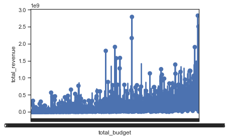

```python
#Point Plot of budget and revenue
sns.pointplot(x="total_budget", y="total_revenue", data=df2);
```

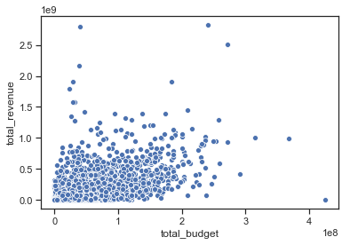

```python
#Scatter Plot of budget and revenue
sns.scatterplot(x="total_budget", y="total_revenue", data=df2);
```

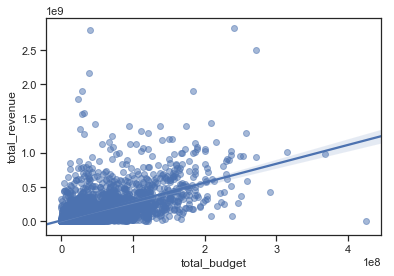

```python
#Scatter plot of budget and revenue, shows better correlation
sns.regplot(x="total_budget", y="total_revenue", data=df2, scatter_kws={'alpha':0.5});
```

> The above plots shows that both the budget and revenue are positivly correlated . Higher the budget of the movie, higher the revenue is.

### Research Question 2 - Is there a correlation between runtime and revenue?

> Plot the graph between movie runtime and revenue.

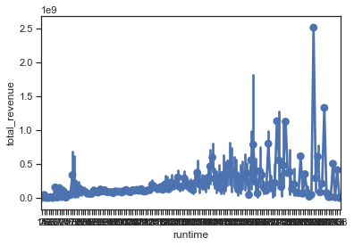

```python
#Point Plot of movie runtime and revenue
sns.pointplot(x="runtime", y="total_revenue", data=df2);
```

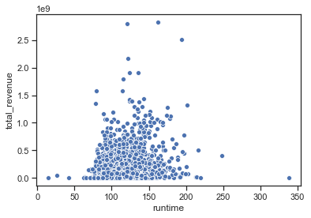

```python
#Scatter Plot of movie runtime and revenue
sns.scatterplot(x="runtime", y="total_revenue", data=df2);
```

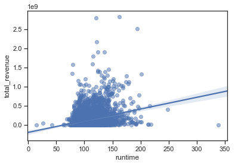

```python
#Scatter plot of movie runtime and revenue, shows better correlation
sns.regplot(x="runtime", y="total_revenue", data=df2, scatter_kws={'alpha':0.5});
```

### Research Question 3 - Is there a correlation between popularity and revenue?

> Plot the graph between movie popularity and revenue.

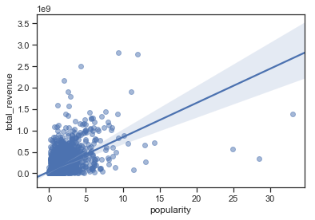

```python
#Scatter plot of popularity and revenue, shows better correlation
sns.regplot(x="popularity", y="total_revenue", data=df2, scatter_kws={'alpha':0.5});
```

```python
#exclude the data where popularity is more than 15
df2_popularity_removeOutliers = df2[df2['popularity'] < 15]
```

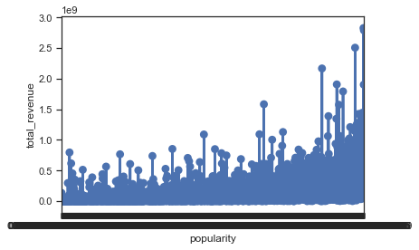

```python
#Plot of popularity and revenue
sns.pointplot(x="popularity", y="total_revenue", data=df2_popularity_removeOutliers);
```

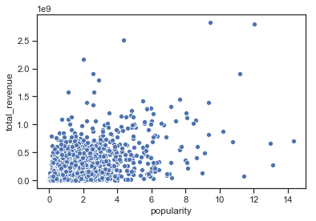

```python
#Plot of popularity and revenue
sns.scatterplot(x="popularity", y="total_revenue", data=df2_popularity_removeOutliers);
```

> Looking at the above graph, we can say that there is definitely a positive correlation between movie popularity and revenue.

### Research Question 4 - Who are the top directors in terms of number of movies they directed?

> Reputed directors traditionally do have a impact on the movie revenue. Lets first find out the directors which directed the most movies. Then compare the revenues made by the movies they directed. We will find out whether a particular director directing a movie has any(if any) significant impact on the revenues.

```python
# Sieve through the dataset by using a group by function and find out the list of directors,
# which produced the most movies in descending order.
# Since the number of directors in this dataset is huge, we shall only consider the top few
# who have directed a greater number of movies.
top_directors = (df2.groupby('director')['original_title'].count()).sort_values(ascending=False)
```

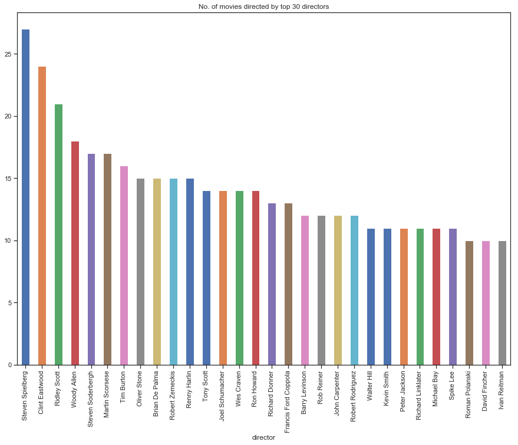

```python
#List of top directors
top_directors[:30].plot(kind='bar', figsize=(15,11), title='No. of movies directed by top 30 directors').yaxis.label.set_visible(False);
```

> Looking at the bar chart, Steven Spielberg, Clint Eastwood, Ridley Scott and Woody Allen are one of the top directors who have directed highest number of movies.

### Research Question 5 - Is there a correlation between average revenue and directors?

> The below code first sieves through dataframe and extracts all those rows which contains the names of the top 30 directors. The for loop extracts the row from the dataframe and keeps on appended it to the df_TopDirectors dataframe.

```python
#Now create a new dataframe which only contain the rows belonging to the movies produced by these directors
df_temp = pd.DataFrame()
for mv_dir,v in top_directors[:30].items():
    df_temp = df_temp.append(df2[df2['director'].str.contains(mv_dir)],ignore_index=True)
df_TopDirectors = df_temp
```

```python
df_TopDirectors.info()
```

```
<class 'pandas.core.frame.DataFrame'>
RangeIndex: 434 entries, 0 to 433
Data columns (total 10 columns):
popularity        434 non-null float64
original_title    434 non-null object
cast              434 non-null object
director          434 non-null object
runtime           434 non-null int64
genres            434 non-null object
release_date      434 non-null datetime64[ns]
release_year      434 non-null int64
total_budget      434 non-null float64
total_revenue     434 non-null float64
dtypes: datetime64[ns](1), float64(3), int64(2), object(4)
memory usage: 34.0+ KB
```

> Once the dataframe which contains the movies directed by the top directors is produced. groupby mean is calculated and is then stored in the df_TopDirectorsRevenue dataframe and the non-essential coloumns which are not required for plotting are removed. Sorting of the revenue is done so that the data is visually clear and appealing.

```python
# take the mean of the revenue produced by all the movies directed by the director.
df_TopDirectorsRevenue = df_TopDirectors.groupby(['director']).mean()
#Extract the relavent coloumns needed for plotting
df_TopDirectorsRevenue =df_TopDirectorsRevenue.drop(df_TopDirectorsRevenue.columns.difference(['director','total_revenue']), 1)
# Sort the total_revenue coloumn in descending order
df_TopDirectorsRevenue = df_TopDirectorsRevenue.sort_values(by='total_revenue', ascending=1)
```

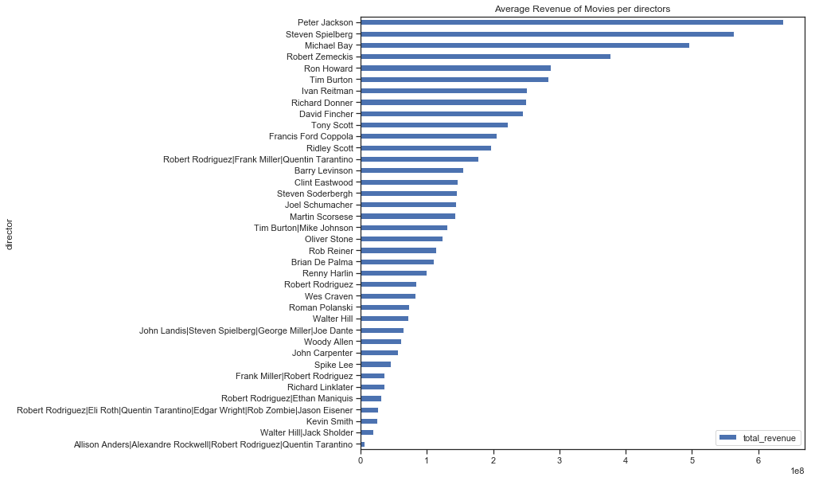

```python
df_TopDirectorsRevenue.plot(kind='barh', figsize=(10, 10), sort_columns='True', title='Average Revenue of Movies per directors' );
```

> Above chart shows that the movies made by top directors like Peter Jackson, Steven Spielberg, Robert Zemerckis, Ron Howard and Tim Burton have made higher reveues.